# Practical ML_Peer-graded Assignment

Qianqian Hu

10/17/2021

### Executive Summary

##### Background

Using devices such as Jawbone Up, Nike FuelBand, and Fitbit it is now possible to collect a large amount of data about personal activity relatively inexpensively. These type of devices are part of the quantified self movement – a group of enthusiasts who take measurements about themselves regularly to improve their health, to find patterns in their behavior, or because they are tech geeks. One thing that people regularly do is quantify how much of a particular activity they do, but they rarely quantify how well they do it. In this project, your goal will be to use data from accelerometers on the belt, forearm, arm, and dumbell of 6 participants. They were asked to perform barbell lifts correctly and incorrectly in 5 different ways. More information is available from the website here: http://groupware.les.inf.puc-rio.br/har (see the section on the Weight Lifting Exercise Dataset).

##### Data

The training data for this project are available here: https://d396qusza40orc.cloudfront.net/predmachlearn/pml-training.csv The test data are available here: https://d396qusza40orc.cloudfront.net/predmachlearn/pml-testing.csv The data for this project come from this source: http://groupware.les.inf.puc-rio.br/har. If you use the document you create for this class for any purpose please cite them as they have been very generous in allowing their data to be used for this kind of assignment.

##### What you should submit

The goal of your project is to predict the manner in which they did the exercise. This is the “classe” variable in the training set. You may use any of the other variables to predict with. You should create a report describing how you built your model, how you used cross validation, what you think the expected out of sample error is, and why you made the choices you did. You will also use your prediction model to predict 20 different test cases.

##### Peer Review Portion

Your submission for the Peer Review portion should consist of a link to a Github repo with your R markdown and compiled HTML file describing your analysis. Please constrain the text of the writeup to < 2000 words and the number of figures to be less than 5. It will make it easier for the graders if you submit a repo with a gh-pages branch so the HTML page can be viewed online (and you always want to make it easy on graders :-).

##### Course Project Prediction Quiz Portion

Apply your machine learning algorithm to the 20 test cases available in the test data above and submit your predictions in appropriate format to the Course Project Prediction Quiz for automated grading.

##### Reproducibility

Due to security concerns with the exchange of R code, your code will not be run during the evaluation by your classmates. Please be sure that if they download the repo, they will be able to view the compiled HTML version of your analysis.

```r
library(dplyr); library(caret); library(utils); library(ggplot2); library(klaR); library(mgcv); library(nlme); library(randomForest)
```

### Read, Clean, Divide Data

**Download and read in data for training and testing data set**

```r
url="https://d396qusza40orc.cloudfront.net/predmachlearn/pml-training.csv"; download.file(url,"./train.csv",method="curl")
url="https://d396qusza40orc.cloudfront.net/predmachlearn/pml-testing.csv"; download.file(url,"./test.csv",method="curl")
df=read.csv("./train.csv"); newdata=read.csv("./test.csv")
```

**Clean data**

```r
df_clean=df[,-c(1:7)] # remove metadata
df_clean=df_clean %>% select_if(colMeans(is.na(.))<0.9) # remove mostly NA columns
df_clean <- df_clean[,-nearZeroVar(df_clean)] # remove near zero variance columns
```

**create training/testing/validation data set by 6:2:2 ratio**

```r
inBuild=createDataPartition(df_clean$classe,p=0.8,list=FALSE); validation=df_clean[-inBuild,]
Index=createDataPartition(df_clean[inBuild,]$classe,p=0.75,list=FALSE); training=df_clean[inBuild,][Index,]; testing=df_clean[inBuild,][-Index,]
```

### Train with single ML algorithms

```r
## A bagging method "treebag"
bag_mod <- train(classe ~.,method="treebag", data=training, trControl = trainControl(method="cv",number=3))
## Recursive Partitioning and Regression Trees "rpart"
rpart_mod <- train(classe ~.,method="rpart", data=training, trControl = trainControl(method="cv",number=3))
## Linear Discriminant Analysis "lda"
lda_mod <- train(classe ~.,method="lda",data=training, trControl = trainControl(method="cv",number=3))
## Naive Bayes "nb"
nb_mod <- train(classe ~.,method="nb",data=training, trControl = trainControl(method="cv",number=3))
## Random Forest "rf"
rf_mod <- train(classe ~.,method="rf", data=training, trControl = trainControl(method="cv",number=3))
## Generalized Boosted Models -- "gbm"
gbm_mod <- train(classe ~.,method="gbm",data=training, trControl = trainControl(method="cv",number=3))
## Support Vector Machines with Linear Kernel "svmLinear"
svm_mod <- train(classe ~.,method="svmLinear",data=training, trControl = trainControl(method="cv",number=3))
```

###### Evaluate in-sample accuracy of each Single model

```r
cbind(
  bag=sum(predict(bag_mod,training[,-53])==training$classe)/dim(training)[1],
  rpart=sum(predict(rpart_mod,training[,-53])==training$classe)/dim(training)[1],
  lda=sum(predict(lda_mod,training[,-53])==training$classe)/dim(training)[1],
  nb=sum(predict(nb_mod,training[,-53])==training$classe)/dim(training)[1],
  rf=sum(predict(rf_mod,training[,-53])==training$classe)/dim(training)[1],
  gbm=sum(predict(gbm_mod,training[,-53])==training$classe)/dim(training)[1],
  svm=sum(predict(svm_mod,training[,-53])==training$classe)/dim(training)[1]
)
```

```
##            bag     rpart       lda        nb rf       gbm       svm
## [1,] 0.9999151 0.4972826 0.7064368 0.7476223  1 0.9752038 0.7919497
```

**I expect out-of-sample error (1-accuracy) to be a little bit higher but very close to in-sample error; eg. for nb_mod, the out-of-sample error should be close to 0.25; but the accuracy ranking among different models should be similar: rf>=bag>=gbm >> svm>nb>lda>rpart**

###### Evaluate out-of-sample accuracy of each Single model

```r
cbind(
  bag=sum(predict(bag_mod,testing[,-53])==testing$classe)/dim(testing)[1],
  rpart=sum(predict(rpart_mod,testing[,-53])==testing$classe)/dim(testing)[1],
  lda=sum(predict(lda_mod,testing[,-53])==testing$classe)/dim(testing)[1],
  nb=sum(predict(nb_mod,testing[,-53])==testing$classe)/dim(testing)[1],
  rf=sum(predict(rf_mod,testing[,-53])==testing$classe)/dim(testing)[1],
  gbm=sum(predict(gbm_mod,testing[,-53])==testing$classe)/dim(testing)[1],
  svm=sum(predict(svm_mod,testing[,-53])==testing$classe)/dim(testing)[1]
)
```

```
##            bag     rpart      lda        nb        rf       gbm       svm
## [1,] 0.9790976 0.4884017 0.701504 0.7336222 0.9885292 0.9587051 0.7812898
```

**Accuracy ranking: rf ≳ treebag ≳ gbm > svm > nb > lda > rpart**  
**Therefore, rf, treebag and gbm are selected to construct ensembling model."**

### Evaluate Stack Model

```r
## Construct combTest using predictiong results of testing data
combTest=data.frame(rf=predict(rf_mod,testing[,-53]), bag=predict(bag_mod,testing[,-53]), gbm=predict(gbm_mod,testing[,-53]),classe=testing$classe)
## run a rf model on the combined test data
stack_mod=train(classe~.,combTest,method="rf")
## Construct combVal using prediction results of validation data
combVal=data.frame(rf=predict(rf_mod,validation[,-53]), bag=predict(bag_mod,validation[,-53]), gbm=predict(gbm_mod,validation[,-53]),classe=validation$classe)
## Evaluate the out-of-sample accuracy of Single models vs stack model
rbind(
  test = c(rf = sum(predict(rf_mod,testing)==testing$classe)/dim(testing)[1],
bag = sum(predict(bag_mod,testing)==testing$classe)/dim(testing)[1], gbm = sum(predict(gbm_mod,testing)==testing$classe)/dim(testing)[1],
stack = sum(predict(stack_mod,combTest)==combTest$classe)/dim(combTest)[1]),
  validation = c(sum(predict(rf_mod,validation)==validation$classe)/dim(validation)[1], sum(predict(bag_mod,validation)==validation$classe)/dim(validation)[1], sum(predict(gbm_mod,validation)==validation$classe)/dim(validation)[1],
sum(predict(stack_mod,combVal)==combVal$classe)/dim(combVal)[1])
)
```

[output not shown]

### Plotting models

[figure not shown]

```r
## rpart_mod tree
rattle::fancyRpartPlot(rpart_mod$finalModel)
```

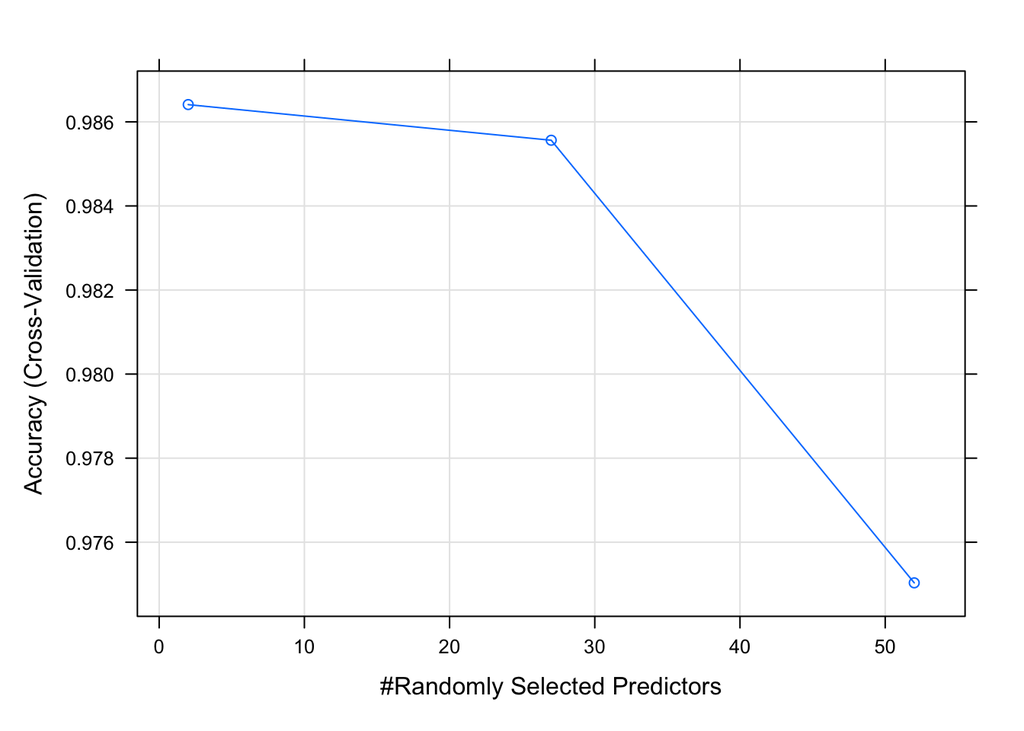

```r
## construct diagnostic plots for models
plot(rf_mod)
```

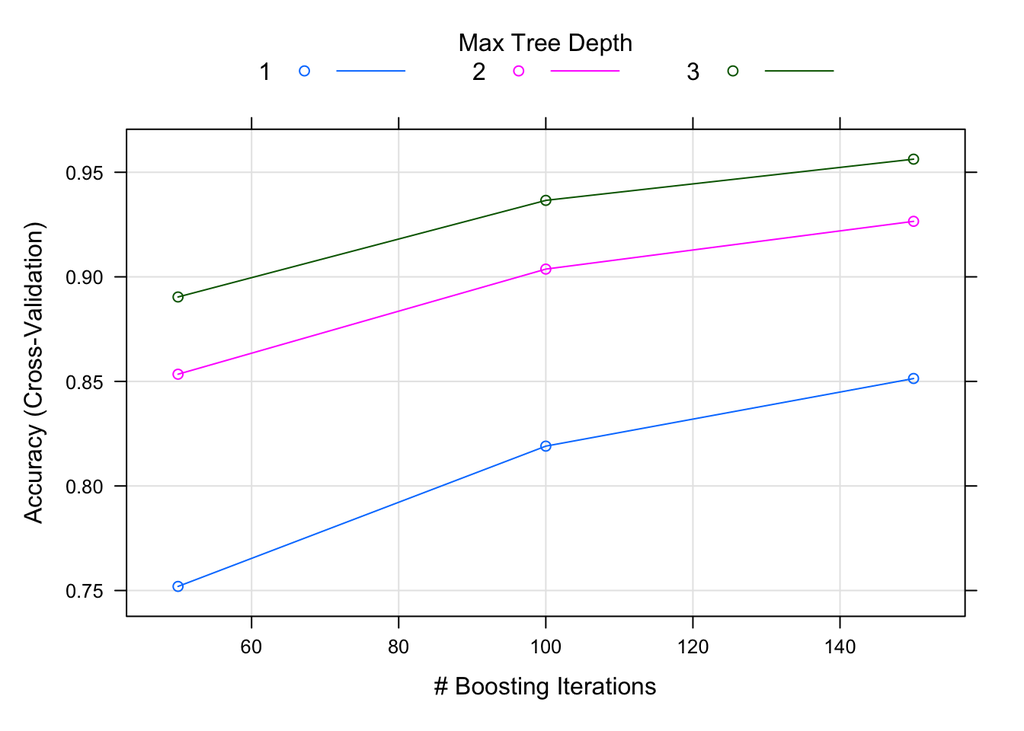

```r
plot(gbm_mod)
```

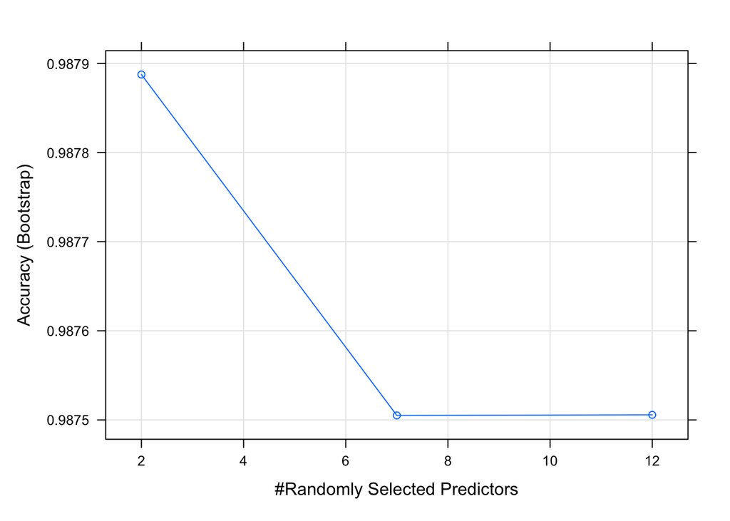

```r
plot(stack_mod)
```